# Raport WUM

Granat, Miziński

17 - 06 - 2019

# 1 Cel

Celem tego projektu jest wykonanie analizy skupień na danych pobrancyh z Centrum Nauki Kopernik. Dane, na których pracowaliśmy pochodziły z obserwacji interakcji 12-latkóW, odwiedzająccyh centrum, z eksponatami.

# 2 Nowa ramka danych

W celu wykonania analizy skupień na danych pobranych z “kapitału wiedzy z Centrum Nauki Kopernik” storzyliśmy na ich podstawie nową ramkę danych. Skupiliśmy się na powiązaniu eksponatów, które wystapiły jako wiersze w naszym zbiorze. Dla każdego znich wyciągnęliśmy interesujące nas informacje, które umieściliśmy w odpowiednich kolumnach. Poniżej pokazaliśmy stworzoną ramkę danych oraz krótki opis znaczenia i sposobu w jaki powstały kolumny naszej ramki danych.

```r
DT::datatable(dane)
```

|  | eksponat | kategorie | galeria | stosOdwiedzen | srCzasSek | srLiczbaOsobTow | srLiczbaOsobTow2 | stosSamotnik | maxOsobTow | stosPatrz | stosDot | stosUzyw | stosEksp | stosOpis | stosAnimator | stosWielOdwiedzin | maxWielOdwiedzin |
| --- | --- | --- | --- | --- | --- | --- | --- | --- | --- | --- | --- | --- | --- | --- | --- | --- | --- |
| 1 | 4D FRAME | 1 |  | 0.0392156862745098 | 53.375 | 0.625 | 0.625 | 0.375 | 1 | 0.375 | 0.125 | 0.5 | 0 | 0.25 | 0 | 0.142857142857143 | 2 |
| 2 | AGORA | 1 |  | 0.00490196078431373 | 1380 | 3 | 3 | 0 | 3 | 0 | 0 | 0 | 0 | 0 | 0 | 0 | 1 |
| 3 | AKSAMITNE DŁONIE | 1 | Człowiek i Środowisko | 0.053921568627451 | 26 | 0.909090909090909 | 0.909090909090909 | 0.272727272727273 | 2 | 0 | 0.272727272727273 | 0.636363636363636 | 0 | 0.181818181818182 | 0 | 0.25 | 3 |
| 4 | ALARM NA STATKU | 1 | Płyń lub Giń | 1.07843137254902 | 130.140909090909 | 1.59545454545455 | 1.48181818181818 | 0.240909090909091 | 5 | 0.0954545454545455 | 0.0636363636363636 | 0.672727272727273 | 0.0681818181818182 | 0.00909090909090909 | 0.0227272727272727 | 0.732394366197183 | 15 |
| 5 | ALEJKA W. ROENTGENA | 1 | Człowiek i Środowisko | 0.00980392156862745 | 17.5 | 0.5 | 0.5 | 0.5 | 1 | 0 | 0 | 1 | 0 | 0 | 0 | 0 | 1 |
| 6 | ANALIZA DNA | 1 | Człowiek i Środowisko | 0.00980392156862745 | 26 | 0.5 | 0.5 | 0.5 | 1 | 0 | 0.5 | 0.5 | 0 | 0 | 0 | 0 | 1 |
| 7 | ANATOMIA | 1 |  | 0.0588235294117647 | 149.416666666667 | 2.16666666666667 | 2 | 0.0833333333333333 | 4 | 0 | 0.0833333333333333 | 0.916666666666667 | 0 | 0 | 0.666666666666667 | 0.2 | 2 |
| 8 | ASTROSELFIE | 1 | Patrz Ziemia | 0.0245098039215686 | 39 | 0.8 | 0.8 | 0.4 | 2 | 0 | 0.8 | 0.2 | 0 | 0 | 0 | 0.25 | 2 |
| 9 | AUKCJA HOLENDERSKA | 1 | Korzenie Cywilizacji | 0.254901960784314 | 150.576923076923 | 1.71153846153846 | 1.44230769230769 | 0.211538461538462 | 8 | 0.326923076923077 | 0.288461538461538 | 0.25 | 0.115384615384615 | 0.192307692307692 | 0.0769230769230769 | 0.19047619047619 | 3 |
| 10 | AUTO | 1 |  | 0.240196078431373 | 108.836734693878 | 1.02040816326531 | 1.02040816326531 | 0.448979591836735 | 3 | 0.387755102040816 | 0.285714285714286 | 0.285714285714286 | 0 | 0.142857142857143 | 0 | 0.590909090909091 | 6 |

[output cut: 629 more lines]

- **eksponat** - nazwa eksponatu
- **kategorie** - kategoria eksponatu
- **galeria** - galeria, w której umieszczony jest eksponat
- **stosOdwiedzen** - stosunek odwiedzeń eksponatu do wszystkich zarejestrowanych wizyt dzieci przy danym eksponacie (możliwy stosunek większy od 1, ze względu na wielokrotne odwiedziny tego samego eksponatu w czasie jednej wizyty)
- **srCzasSek** - średni czas spędzony przy eksponacie podczas jego odwiedzin
- **srLiczbaOsobTow** - średnia liczba osób towarzyszących odwiedzającemu podczas wizyty
- **srLiczbaOsobTow2** - średnia liczba osób towarzyszących odwiedzającemu podczas wizyty, uzyskana z analizy wideo
- **stosSamotnik** - stosunek odwiedzin osoby bez osoby towarzyszącej do wszystkich zarejestrowanych wizyt dzieci przy danym eksponacie
- **maxOsobTow** - maksymalna zarejestrowana liczba osób towarzyszących odwiedzjących eksponat podczas jednej wizyty
- **stosPatrz** - stosunek odwiedzających, których interakcja z eksponatem polegała tylko na “patrzeniu”, do wszystkich zarejestrowanych wizyt dzieci przy danym eksponacie
- **stosDot** - stosunek odwiedzających, których interakcja z eksponatem polegała na “dotykaniu”, do wszystkich zarejestrowanych wizyt dzieci przy danym eksponacie
- **stosUzyw** - stosunek odwiedzających, których interakcja z eksponatem polegała na “używaniu”, do wszystkich zarejestrowanych wizyt dzieci przy danym eksponacie
- **stosEksp** - stosunek odwiedzających, których interakcja z eksponatem polegała na “eksperymentowaniu”, do wszystkich zarejestrowanych wizyt dzieci przy danym eksponacie
- **stosOpis** - stosunek odwiedzających, którzy czytali opis przy eksponacie, do wszystkich zarejestrowanych wizyt dzieci przy danym eksponacie
- **stosAnimator** - stosunek odwiedzających, którzy prowadzili interakcję z animatorem, do wszystkich zarejestrowanych wizyt dzieci przy danym eksponacie
- **stosWielOdwiedzin** - stosunek odwiedzających, którzy wielokrotnie odwiedzali dany eksponat, do wszystkich zarejestrowanych wizyt dzieci przy danym eksponacie
- **maxWielOdwiedzin** - maksymalna liczba wielokrotnych odwiedzeń eksponatu podczas jednej wizyty w centrum nauki

## 2.1 Korelacja zmiennych

Po stworzeniu nowej ramki danych sprawdziliśm,y korelacje zmiennych, której wykres zamieściliśmy poniżej.

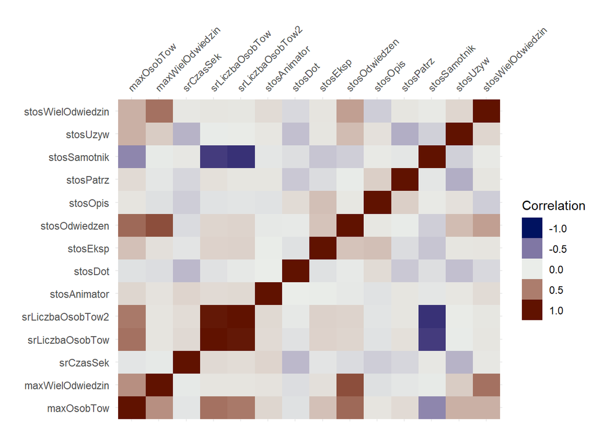

```r
vis_cor(dane[-c(1,2,3)])
```

Jak widać, niektóre zmienne są ze sobą silnie skorelowane, dlatego niektóre z nich usunęliśmy. Ramkę danych, na której będziemy pracować w dalszej części projektu, pokazano poniżej.

```r
dane2 <- dane[-c(2,3,7,8)]
DT::datatable(dane2)
```

|  | eksponat | stosOdwiedzen | srCzasSek | srLiczbaOsobTow | maxOsobTow | stosPatrz | stosDot | stosUzyw | stosEksp | stosOpis | stosAnimator | stosWielOdwiedzin | maxWielOdwiedzin |
| --- | --- | --- | --- | --- | --- | --- | --- | --- | --- | --- | --- | --- | --- |
| 1 | 4D FRAME | 0.0392156862745098 | 53.375 | 0.625 | 1 | 0.375 | 0.125 | 0.5 | 0 | 0.25 | 0 | 0.142857142857143 | 2 |
| 2 | AGORA | 0.00490196078431373 | 1380 | 3 | 3 | 0 | 0 | 0 | 0 | 0 | 0 | 0 | 1 |
| 3 | AKSAMITNE DŁONIE | 0.053921568627451 | 26 | 0.909090909090909 | 2 | 0 | 0.272727272727273 | 0.636363636363636 | 0 | 0.181818181818182 | 0 | 0.25 | 3 |
| 4 | ALARM NA STATKU | 1.07843137254902 | 130.140909090909 | 1.59545454545455 | 5 | 0.0954545454545455 | 0.0636363636363636 | 0.672727272727273 | 0.0681818181818182 | 0.00909090909090909 | 0.0227272727272727 | 0.732394366197183 | 15 |
| 5 | ALEJKA W. ROENTGENA | 0.00980392156862745 | 17.5 | 0.5 | 1 | 0 | 0 | 1 | 0 | 0 | 0 | 0 | 1 |
| 6 | ANALIZA DNA | 0.00980392156862745 | 26 | 0.5 | 1 | 0 | 0.5 | 0.5 | 0 | 0 | 0 | 0 | 1 |
| 7 | ANATOMIA | 0.0588235294117647 | 149.416666666667 | 2.16666666666667 | 4 | 0 | 0.0833333333333333 | 0.916666666666667 | 0 | 0 | 0.666666666666667 | 0.2 | 2 |
| 8 | ASTROSELFIE | 0.0245098039215686 | 39 | 0.8 | 2 | 0 | 0.8 | 0.2 | 0 | 0 | 0 | 0.25 | 2 |
| 9 | AUKCJA HOLENDERSKA | 0.254901960784314 | 150.576923076923 | 1.71153846153846 | 8 | 0.326923076923077 | 0.288461538461538 | 0.25 | 0.115384615384615 | 0.192307692307692 | 0.0769230769230769 | 0.19047619047619 | 3 |
| 10 | AUTO | 0.240196078431373 | 108.836734693878 | 1.02040816326531 | 3 | 0.387755102040816 | 0.285714285714286 | 0.285714285714286 | 0 | 0.142857142857143 | 0 | 0.590909090909091 | 6 |

[output cut: 629 more lines]

## 2.2 Histogramy zmiennych

Poniżej pokazano histogramy zmiennych.

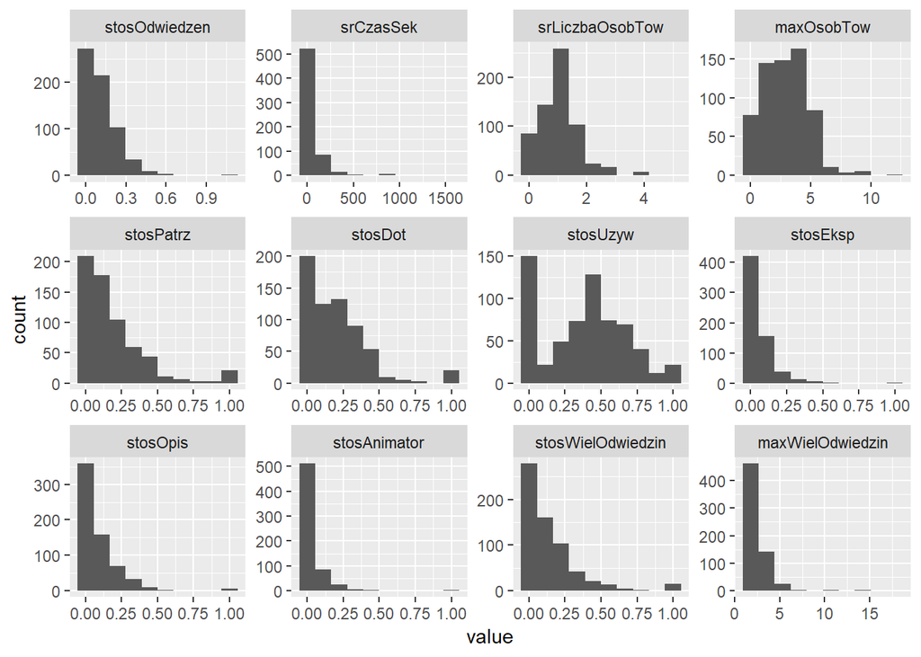

```r
d <- melt(dane2)
ggplot(d,aes(x = value)) +
  facet_wrap(~variable,scales = "free") +
  geom_histogram(bins = 10)
```

# 3 Wizualizacja zbioru

Uznaliśmy, że kluczową zmienną przy klasteryzacji może być popularność danego eksponatu wyznaczana przez liczbę odwiedzin. Zwizualizowaliśmy zbiór przy pomocy **PCA** i oznaczyliśmy popularne eksponaty przy zadanym przez nas threshholdzie popularności.

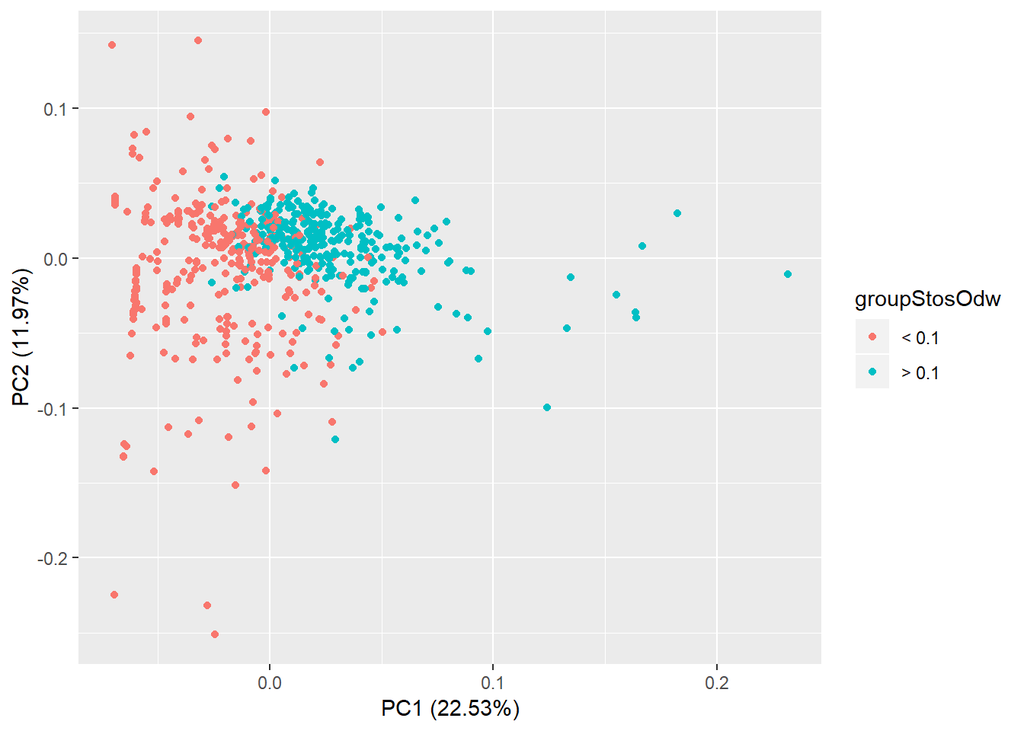

```r
library(ggfortify)
df <- dane2[-1]
df.stand <- scale(df)
df_clus <- df.stand
#ile odwiedzalo ekspnaty
#kolor - stosunek odwiedzen >0.1
df2 <- df
df2$groupStosOdw <- ifelse(df$stosOdwiedzen > 0.1, "> 0.1", "< 0.1")
df2$groupStosOdw <- as.factor(df2$groupStosOdw)

autoplot(prcomp(df.stand), data = df2[-1], colour = "groupStosOdw")
```

Klastry wydają się być wystarczająco dobrze separowalne. Zajmiemy się zatem teraz liczbą klastrów.

# 4 Liczba klastrów

Przy użyciu biblioteki **NbClust** określę na ile grup dzielić zbiór. Ponieważ zbiór ma jedynie 639 obserwacji sprawdzam wartości indeksów dla liczby klastrów od 2 do 10.

Sprawdzam indeksy “Gap statistic”, “Total within sum of square” i “Silhouette” dla każdego z algorytmów.

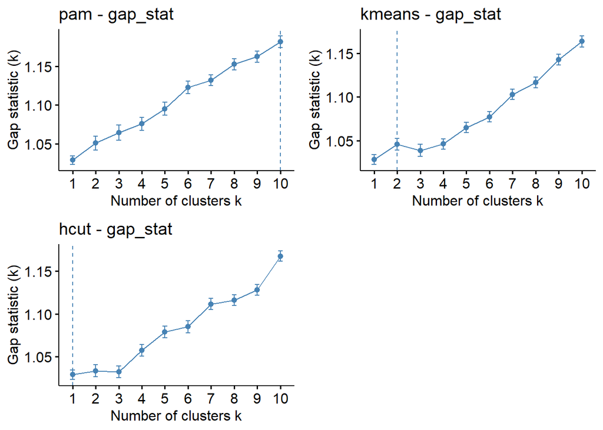

```r
grid.arrange(
fviz_nbclust(df_clus, pam, method="gap_stat") + labs(title = "pam - gap_stat"),
fviz_nbclust(df_clus, kmeans, method="gap_stat") + labs(title = "kmeans - gap_stat"),
fviz_nbclust(df_clus, hcut, method="gap_stat") + labs(title = "hcut - gap_stat"), nrow =2 )
```

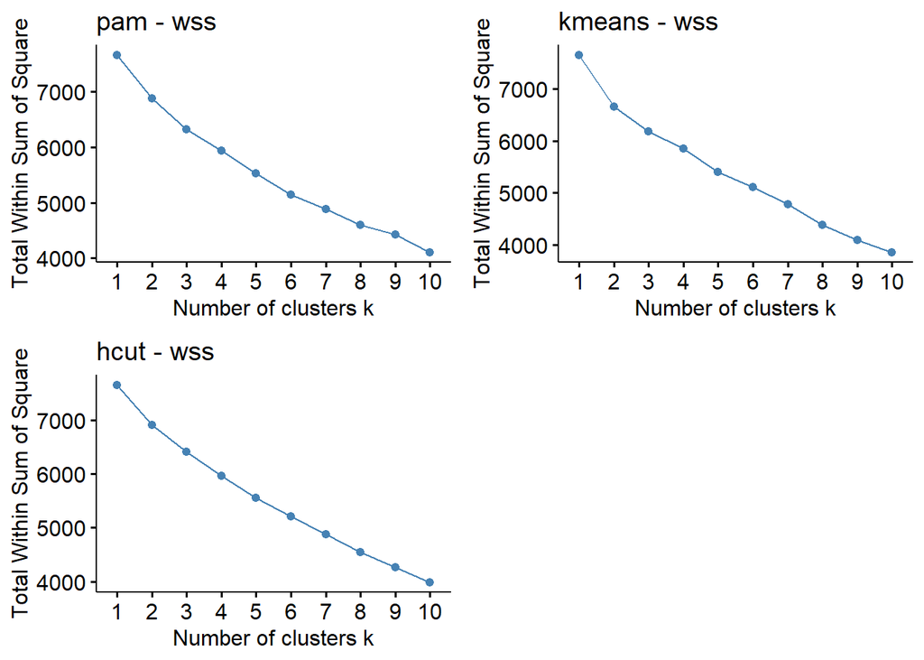

```r
grid.arrange(
fviz_nbclust(df_clus, pam, method="wss") + labs(title = "pam - wss"),
fviz_nbclust(df_clus, kmeans, method="wss") + labs(title = "kmeans - wss"),
fviz_nbclust(df_clus, hcut, method="wss") + labs(title = "hcut - wss"), nrow = 2)
```

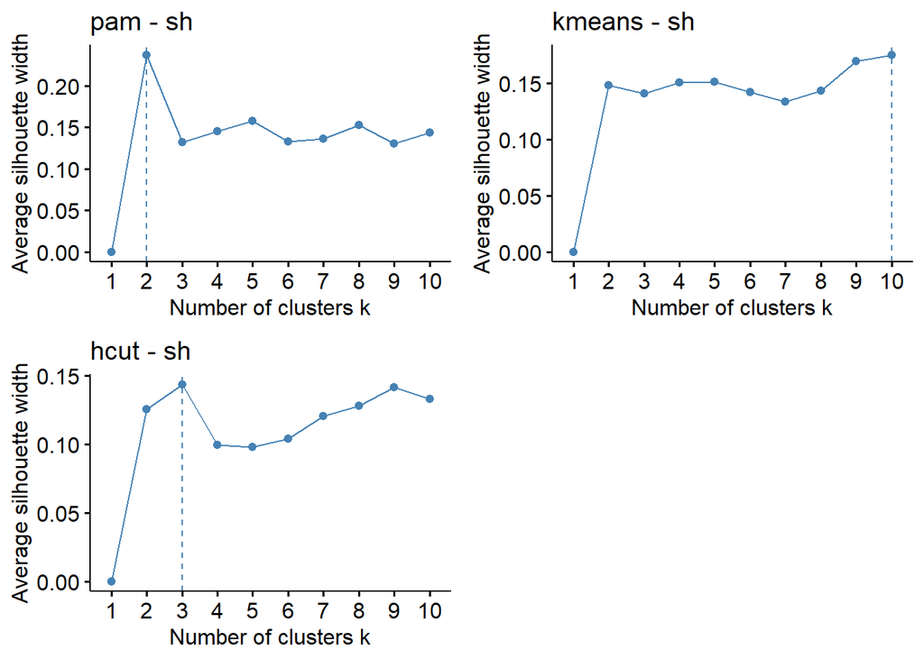

```r
grid.arrange(
fviz_nbclust(df_clus, pam, method="silhouette") + labs(title = "pam - sh"),
fviz_nbclust(df_clus, kmeans, method="silhouette") + labs(title = "kmeans - sh"),
fviz_nbclust(df_clus, hcut, method="silhouette") + labs(title = "hcut - sh"),nrow = 2)
```

Widzimy, uśredniając wnioski z wykresów, że 2 jest liczbą klastrów najlepiej dzielącą nasz zbiór dla algorytmów **K-Means** oraz **PAM**, a 3 dla **hcut**.

# 5 Porównanie algorytmów

Porównam działanie na naszym zbiorze algorytmów **k-means**, **pam** oraz **agnes**, a zatem algorytmy oparte na centroidach, medoidach oraz algorytm hierarchiczny dla 2 oraz 3 klastrów, ponieważ takie liczby otrzymaliśmy w poprzednim kroku.

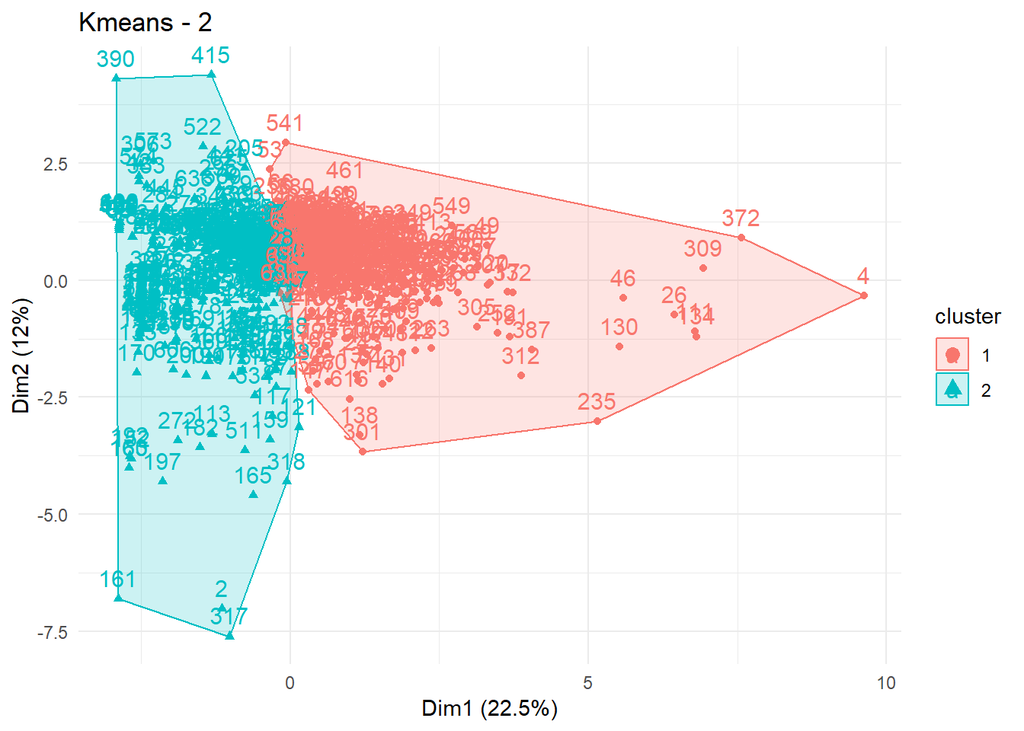

```r
pam.res2 <- pam(df_clus, 2)
km.res2 <- kmeans(df_clus, 2)
hcut.res2 <- hcut(df_clus, k = 2, hc_func = "agnes")

fviz_cluster(km.res2, data = df_clus, frame.type = "convex")+
  theme_minimal() + labs(title = "Kmeans - 2")
```

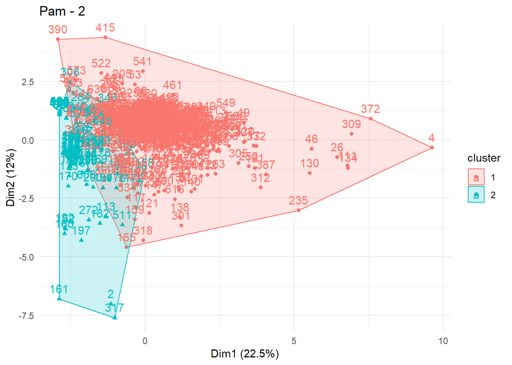

```r
fviz_cluster(pam.res2, data = df_clus, frame.type = "convex")+
  theme_minimal() + labs(title = "Pam - 2")
```

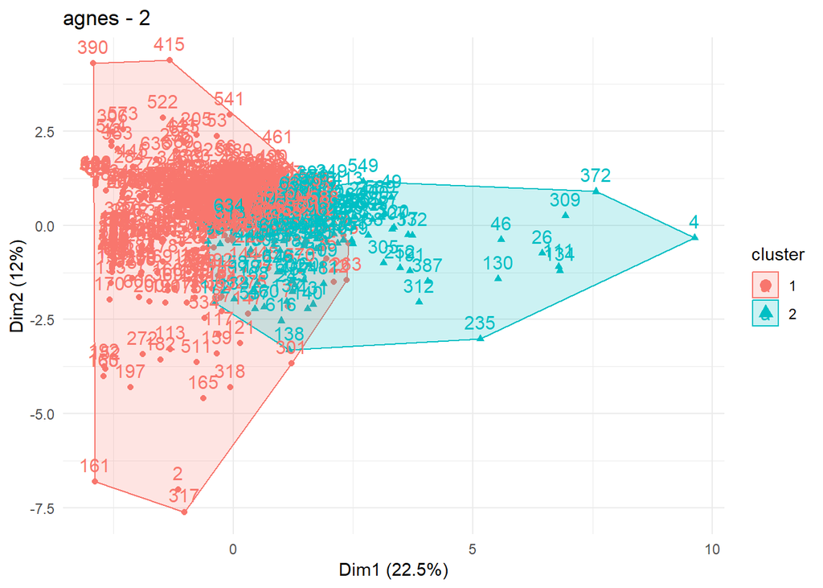

```r
fviz_cluster(hcut.res2, data = df_clus, frame.type = "convex")+
  theme_minimal() + labs(title = "agnes - 2")
```

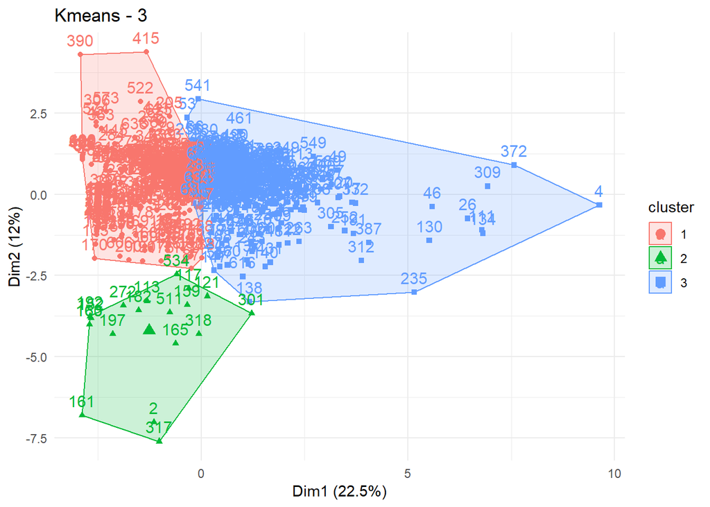

```r
pam.res3 <- pam(df_clus, 3)
km.res3 <- kmeans(df_clus, 3)
hcut.res3 <- hcut(df_clus, k = 3, hc_func = "agnes")

fviz_cluster(km.res3, data = df_clus, frame.type = "convex")+
  theme_minimal() + labs(title = "Kmeans - 3")
```

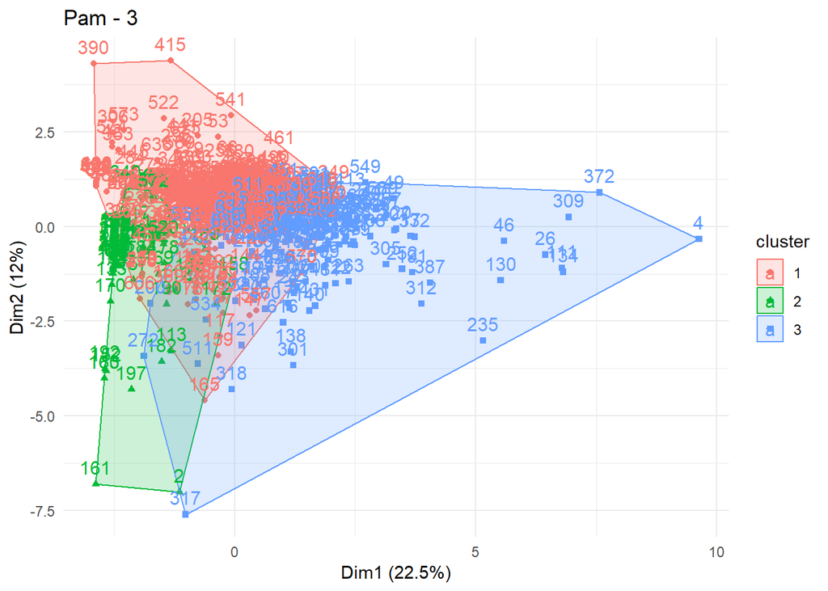

```r
fviz_cluster(pam.res3, data = df_clus, frame.type = "convex")+
  theme_minimal() + labs(title = "Pam - 3")
```

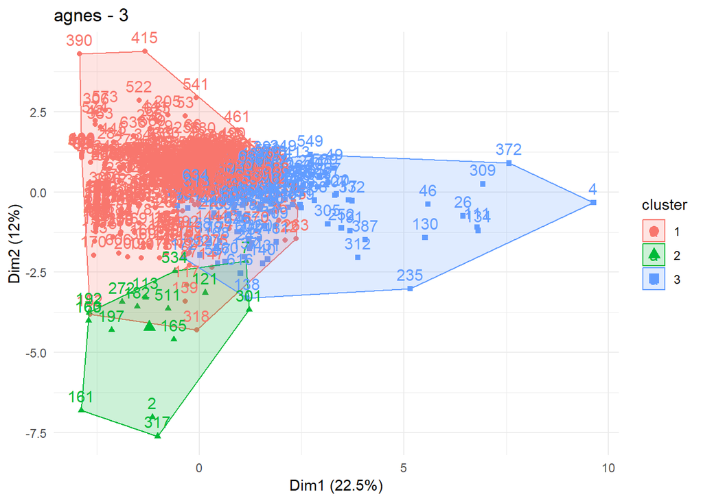

```r
fviz_cluster(hcut.res3, data = df_clus, frame.type = "convex")+
  theme_minimal() + labs(title = "agnes - 3")
```

Na podstawie wizualizacji poszczególnych klasteryzacji można dojść do wniosku, że **K-Means** dla 2 klastrów najlepiej dzieli nasz zbiór. Sprawdźmy jednak miary wewnętrzne dla przeprowadzonych klasteryzacji.

```r
library(clValid)
internal <- clValid(df_clus, nClust = 2:3, clMethods = c("kmeans","agnes","pam"), validation = "internal", maxitems = 1000)
summary(internal)
```

```
##
## Clustering Methods:
##  kmeans agnes pam
##
## Cluster sizes:
##  2 3
##
## Validation Measures:
##                             2        3
##
## kmeans Connectivity  227.4865 232.3357
##        Dunn            0.0470   0.0470
##        Silhouette      0.1482   0.1506
## agnes  Connectivity    2.9290  10.7615
##        Dunn            0.3356   0.2135
##        Silhouette      0.5844   0.5596
## pam    Connectivity  103.8183 245.4313
##        Dunn            0.0535   0.0292
##        Silhouette      0.2372   0.1321
##
## Optimal Scores:
##
##              Score  Method Clusters
## Connectivity 2.9290 agnes  2
## Dunn         0.3356 agnes  2
## Silhouette   0.5844 agnes  2
```

Jak wiemy indeksy Dunna i sylwetki powinny być jak największe,a Connectivity jak najmniejsze. Algorytm hierarchiczny **agnes** dla 2 klastrów uzyskał najlepszy wynik. Rzeczywiście jeśli porównamy wynik działania tego algorytmu z naszą pierwszą hipotezą zauważymy bardzo podobny podział.

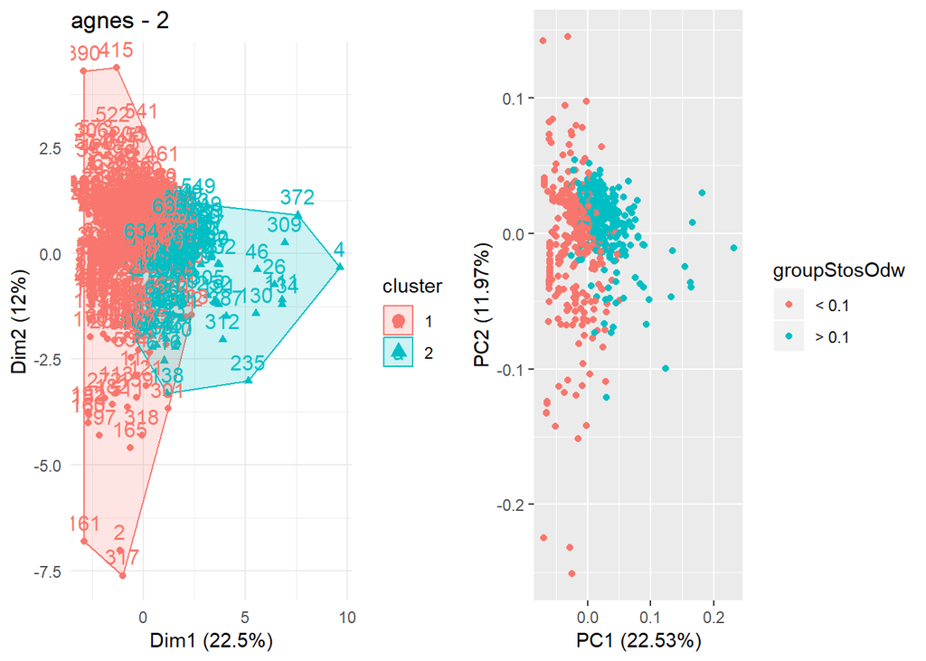

```r
grid.arrange(
  fviz_cluster(hcut.res2, data = df_clus, frame.type = "convex")+
  theme_minimal() + labs(title = "agnes - 2"),
  autoplot(prcomp(df.stand), data = df2[-1], colour = "groupStosOdw"), nrow = 1
)
```

Ponadto na wykresie typu **biplot** możemy zauważyć, że zmienne powiązane z popularnością eksponatu takie jak liczba wielokrotnych odwiedzin czy stosunek odwiedzeń silnie wpływają na wynik klasteryzacji.

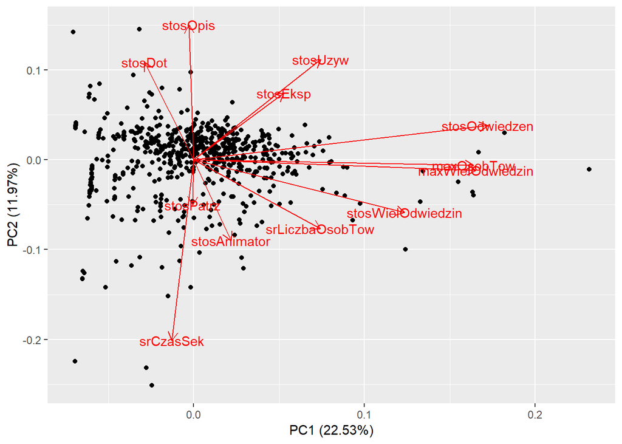

```r
autoplot(stats::prcomp(df_clus, scale=TRUE), label = FALSE, loadings.label = TRUE)
```

Podsumowując uważamy, że algorytm **agnes** dla liczby klastrów = 2 najlepiej podzielił nasz zbiór i możemy przyjąć hipotezę, że klastrami tymi są bardziej i mniej popularne eksponaty.